# Homework 3 Answer Key

## Task 1:

### Problem Description

Farmers need to understand the biology of plants and their responses to fertilizers to maximize yield. You will help farmers make predictions on their yields by running non-linear least squares on experimental growth data for three grains in Greece. Additionally, you will assess the response of the grains to fertlizer. You will recreate the model examples of [Archontoulis, S.V. and Miguez, F.E. (2015)](https://acsess.onlinelibrary.wiley.com/doi/10.2134/agronj2012.0506). Read the paper to acquire more insight into nonlinear least squares and its application in agriculture. The data used by them and soon by you can accessed by installing the `nlraa` package and then using `library(nlraa)`. The data is stored in an object called `sm`.

**Write a brief description of the data including variable names and structure**. Use the metadata and descriptions from the paper to assist you. Create a finalized summary table of the data in your report.

Choosing a model is step 1 of our NLS process. The paper describes 77 potential functions. Let’s use the Beta function from Table 1 Equation 2.5 of Archontoulis, S.V. and Miguez, F.E. (2015). It might be hard to read so I wrote it out here.

$$y=y_{max}(1+\frac{t_e-t}{t_e-t_m})(\frac{t}{t_e})^{\frac{t_e}{t_e-t_m}}$$

**Briefly describe what each parameter generally means (Read the paper).**

Write a function in R to model the Beta Function. The paper uses option 4 for guesses by creating a starting grid to show off a new function. They also indicate guesses can be acquired by examining the data. Create a plot against the data to find some potential starting values for your nls analysis. In your final report include the code, but NOT the plot you used to feed guesses.

Filter out observations from the sorgum fields with high inputs and run an NLS model to predict yield for any given day of the year. **Make a good looking table** showing the selected parameter values, standard errors, and p-values of the estimated parameters. **Graph the fitted model on top of the maize data.**

Run NLS models for all 24 combinations of plot, input level, and crop type using purrr. For each species, which model had the lowest RMSE? **Show a table of the RMSE and chosen parameter values of the best fitted models for each species.**

Finally, **filter to plot 1 and recreate Figure 7 of the paper.** Don’t worry about adding confidence intervals on the data points. How does more fertilizer impact yield for all three grains?

Hints:

- I would separate dataframes one of the filtered data and another of the model predictions with a vector of days from 141 to 306. Then create two figures for each input and join them with patchwork or cowplot.
- Filter observations of predicted yield for maize when day of year is less than 263. Otherwise your graph is going to look weird.

## Solution

```r
#load data and packages
library(tidyverse)
library(nlraa)
library(knitr)
library(kableExtra)
library(broom)
library(patchwork)

sm_clean<-sm |>
  janitor::clean_names()
```

### Define Beta Function

```r
beta_fcn<-function(ymax,te,tm,data){
  out=ymax*(1+(te-data)/(te-tm))*(data/te)^(te/(te-tm))

  return(out)
}
```

### Find Guesses by graphing

```r
doy_vec=seq(141,303,by=1)

#Input values to see what it looks against the data
test<-beta_fcn(40,250,200,doy_vec)

test_df<-data.frame(doy_vec,test)

ggplot(data=sm_clean,aes(x=doy,y=yield))+
  geom_point(aes(shape=crop))+
  geom_line(data=test_df,aes(x=doy_vec,y=test))
```

### Run single nls

```r
sorg<-sm_clean |>
  filter(crop=="S" & input==2)

sorg_nls<-nls(yield~beta_fcn(ymax,te,tm,doy),
           data=sorg,
           start=list(ymax=20,te=240,tm=200))
```

```r
tidy(sorg_nls) |>
  kable(col.names = c("Variable","Estimate","Standard Error","Statistic","p-value"))
```

Table 1: Estimates of Beta Growth function of Sorghum from Non Linear Least Squares

| Variable | Estimate | Standard Error | Statistic | p-value |
| --- | --- | --- | --- | --- |
| ymax | 39.82043 | 2.248862 | 17.70692 | 0 |
| te | 281.58626 | 2.080747 | 135.32944 | 0 |
| tm | 244.77728 | 3.511954 | 69.69832 | 0 |

### Purrr runs

```r
## Set up a purrr function to loop over the other
nls_fcn<-function(df){
  out<-nls(yield~beta_fcn(ymax,te,tm,doy),
                 data=df,
                 start=list(ymax=20,te=240,tm=200))

  return(out)
}

rmse<-function(x,y){
  (x-y)^2 |> mean() |> sqrt()
}

## Create dataframe
models<-sm_clean |>
  group_by(crop,input,block) |>
  nest() |>
  mutate(nls_model=map(.x=data,~nls_fcn(.x))) |>
  mutate(smooth=map(.x=nls_model,~predict(.x,newdata=list(doy=seq(147,306))))) |>
  mutate(predict=map(.x=nls_model,~predict(.x))) |>
  mutate(coeff=map(.x=nls_model,~broom::tidy(.x))) |>
  mutate(rmse=map2_dbl(.x=predict,.y=data,~rmse(.x,.y$yield)))


## Let's extract best models for each crop

rmse_df<-models |>
  group_by(crop) |>
  slice_min(rmse) |>
  select(block,input,crop,rmse,coeff) |>
  unnest(coeff)
```

```r
#MAize table
rmse_df |>
  filter(crop=="M") |>
  select(-crop) |>
  kable()
# Sorghum
rmse_df |>
  filter(crop=="S") |>
  kable()
# Wheat
rmse_df |>
  filter(crop=="F") |>
  select(-crop) |>
  kable()
```

Table 2: NLS Coefficients on best models for each crop

(a) Maize

| crop | block | input | rmse | term | estimate | std.error | statistic | p.value |
| --- | --- | --- | --- | --- | --- | --- | --- | --- |
| M | 4 | 2 | 0.8106605 | ymax | 18.9311 | 0.8396975 | 22.54515 | 5e-07 |
| M | 4 | 2 | 0.8106605 | te | 252.5749 | 1.8691750 | 135.12642 | 0e+00 |
| M | 4 | 2 | 0.8106605 | tm | 225.2284 | 1.9262837 | 116.92379 | 0e+00 |

(b) Sorghum

| block | input | crop | rmse | term | estimate | std.error | statistic | p.value |
| --- | --- | --- | --- | --- | --- | --- | --- | --- |
| 2 | 1 | S | 2.220553 | ymax | 31.34739 | 2.047997 | 15.30636 | 1.2e-06 |
| 2 | 1 | S | 2.220553 | te | 278.34652 | 1.817126 | 153.17957 | 0.0e+00 |
| 2 | 1 | S | 2.220553 | tm | 245.77418 | 3.815020 | 64.42277 | 0.0e+00 |

(c) Wheat

| crop | block | input | rmse | term | estimate | std.error | statistic | p.value |
| --- | --- | --- | --- | --- | --- | --- | --- | --- |
| F | 2 | 1 | 1.821862 | ymax | 29.05637 | 1.657635 | 17.52881 | 5e-07 |
| F | 2 | 1 | 1.821862 | te | 280.42964 | 1.838956 | 152.49391 | 0e+00 |
| F | 2 | 1 | 1.821862 | tm | 244.99873 | 3.538545 | 69.23714 | 0e+00 |

```r
## Unnest predictions from the data and clean maize data
un_df<-models |>
  filter(block==1) |>
  tidyr::unnest(smooth) |>
  mutate(doy=seq(147,306)) |>
  filter(!(doy>263 & crop=="M"))

# Create a dataframe to add corn data
hi_filt<-sm_clean |>
  filter(block==1 & input==2)

low_filt<-sm_clean |>
  filter(block==1 & input==1)

## Make two graphs

hi_plot<-un_df |>
  filter(block==1 & input==2) |>
  ggplot()+
  geom_point(data=hi_filt,aes(x=doy,y=yield,shape=crop))+
  geom_line(aes(x=doy,y=smooth,linetype=crop))+
  ylim(c(0,50))+
  theme_minimal()+
  labs(x="Day of Year",y="Yield")

low_plot<-un_df |>
  filter(block==1 & input==1) |>
  ggplot()+
  geom_point(data=low_filt,aes(x=doy,y=yield,shape=crop))+
  geom_line(aes(x=doy,y=smooth,linetype=crop))+
  ylim(c(0,50))+
  theme_minimal()+
  labs(x="Day of Year",y="Yield")
```

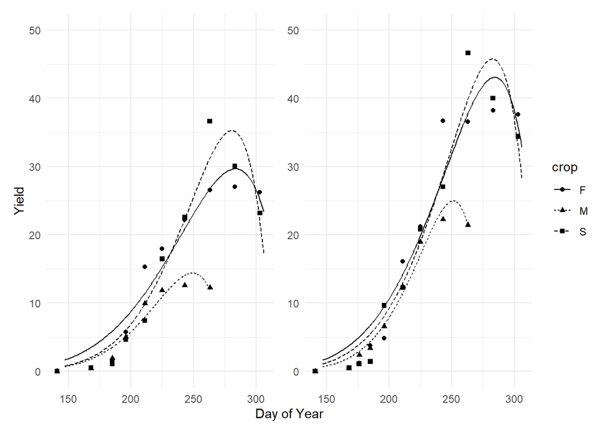

```r
low_plot+hi_plot+plot_layout(guides = "collect",axis_titles = "collect")
```